# HW9_training_arodriguezmu

ALVI RODRIGUEZ

INTRO TO DATA SCIENCE

12/4/2020

```r
#The packages I've used:
library(tidyverse)
library(GGally)
library(broom)
library(modelr)
library(ggplot2)
library(dplyr)
```

```r
# configuring figure size
options(repr.plot.width = 6, repr.plot.height = 4)

# colorblind-friendly color palette
cbPalette <- c('#999999', '#E69F00', '#56B4E9', '#009E73', '#0072B2', '#D55E00', '#CC79A7', '#F0E442')
```

```r
nba <- read_csv("nba2k20-clean.csv")
head(nba)
```

A tibble: 6 × 14

| full_name <chr> | rating <dbl> | jersey <chr> | team <chr> | position <chr> | birth_year <dbl> | height <dbl> | weight <dbl> | salary <dbl> | country <chr> | draft_year <dbl> | draft_round <dbl> | draft_pick <dbl> | college <chr> |
| --- | --- | --- | --- | --- | --- | --- | --- | --- | --- | --- | --- | --- | --- |
| LeBron James | 97 | #23 | Los Angeles Lakers | F | 1984 | 2.06 | 250 | 37436858 | USA | 2003 | 1 | 1 | NA |
| Kawhi Leonard | 97 | #2 | Los Angeles Clippers | F | 1991 | 2.01 | 225 | 32742000 | USA | 2011 | 1 | 15 | San Diego State |
| Giannis Antetokounmpo | 96 | #34 | Milwaukee Bucks | SF | 1994 | 2.11 | 242 | 25842697 | Greece | 2013 | 1 | 15 | NA |
| Kevin Durant | 96 | #7 | Brooklyn Nets | F | 1988 | 2.08 | 230 | 37199000 | USA | 2007 | 1 | 2 | Texas |
| James Harden | 96 | #13 | Houston Rockets | G | 1989 | 1.96 | 220 | 38199000 | USA | 2009 | 1 | 3 | Arizona State |
| Stephen Curry | 95 | #30 | Golden State Warriors | G | 1988 | 1.91 | 185 | 40231758 | USA | 2009 | 1 | 7 | Davidson |

```r
#Here is the 60-40 train-test randomized split.
#For this assignment I'll be using nba_train
set.seed(42)

nba <- unite(nba, full_name, rating, col = 'name_rating', sep = '_', remove = FALSE)

name_rating <- nba %>% select(name_rating) %>% unique() %>% unlist(use.names = FALSE)

train_names <-  sample(name_rating, ceiling(length(name_rating) * 0.6))

train_nba <- nba %>% filter(name_rating %in% train_names)

glimpse(train_nba)

test_names <- setdiff(name_rating, train_names)

test_nba <- nba %>% filter(name_rating %in% test_names)

glimpse(test_nba)
```

```
Rows: 258
Columns: 15
$ name_rating <chr> "LeBron James_97", "Kawhi Leonard_97", "Giannis Antetok...
$ full_name   <chr> "LeBron James", "Kawhi Leonard", "Giannis Antetokounmpo...
$ rating      <dbl> 97, 97, 96, 96, 96, 95, 91, 90, 90, 89, 88, 88, 88, 87,...
$ jersey      <chr> "#23", "#2", "#34", "#7", "#13", "#30", "#21", "#15", "...
$ team        <chr> "Los Angeles Lakers", "Los Angeles Clippers", "Milwauke...
$ position    <chr> "F", "F", "SF", "F", "G", "G", "C", "C", "G", "G", "G",...
$ birth_year  <dbl> 1984, 1991, 1994, 1988, 1989, 1988, 1994, 1995, 1988, 1...
$ height      <dbl> 2.06, 2.01, 2.11, 2.08, 1.96, 1.91, 2.13, 2.13, 1.91, 1...
$ weight      <dbl> 250, 225, 242, 230, 220, 185, 250, 253, 190, 205, 220, ...
$ salary      <dbl> 37436858, 32742000, 25842697, 37199000, 38199000, 40231...
$ country     <chr> "USA", "USA", "Greece", "USA", "USA", "USA", "Cameroon"...
$ draft_year  <dbl> 2003, 2011, 2013, 2007, 2009, 2009, 2014, 2014, 2008, 2...
$ draft_round <dbl> 1, 1, 1, 1, 1, 1, 1, 2, 1, 1, 1, 1, 1, 1, 1, 1, 1, 1, 1...
```

[output cut: 19 more lines]

```r
head(train_nba)
```

A tibble: 6 × 15

| name_rating <chr> | full_name <chr> | rating <dbl> | jersey <chr> | team <chr> | position <chr> | birth_year <dbl> | height <dbl> | weight <dbl> | salary <dbl> | country <chr> | draft_year <dbl> | draft_round <dbl> | draft_pick <dbl> | college <chr> |
| --- | --- | --- | --- | --- | --- | --- | --- | --- | --- | --- | --- | --- | --- | --- |
| LeBron James_97 | LeBron James | 97 | #23 | Los Angeles Lakers | F | 1984 | 2.06 | 250 | 37436858 | USA | 2003 | 1 | 1 | NA |
| Kawhi Leonard_97 | Kawhi Leonard | 97 | #2 | Los Angeles Clippers | F | 1991 | 2.01 | 225 | 32742000 | USA | 2011 | 1 | 15 | San Diego State |
| Giannis Antetokounmpo_96 | Giannis Antetokounmpo | 96 | #34 | Milwaukee Bucks | SF | 1994 | 2.11 | 242 | 25842697 | Greece | 2013 | 1 | 15 | NA |
| Kevin Durant_96 | Kevin Durant | 96 | #7 | Brooklyn Nets | F | 1988 | 2.08 | 230 | 37199000 | USA | 2007 | 1 | 2 | Texas |
| James Harden_96 | James Harden | 96 | #13 | Houston Rockets | G | 1989 | 1.96 | 220 | 38199000 | USA | 2009 | 1 | 3 | Arizona State |
| Stephen Curry_95 | Stephen Curry | 95 | #30 | Golden State Warriors | G | 1988 | 1.91 | 185 | 40231758 | USA | 2009 | 1 | 7 | Davidson |

### What is the relationship between height and salary in the nba?

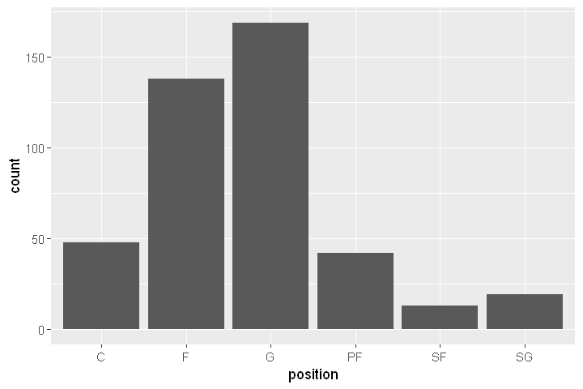

```r
ggplot(nba, aes(x = position)) +
    geom_bar()

Save <- TRUE

if (Save == TRUE) ggsave('plot1.png', width = 7, height = 5)
```

```r
summary_nba_height <- train_nba %>%
    group_by(height) %>%
    summarize(avg_salary = mean(salary, na.rm = TRUE)) %>%
    na.omit() %>%
    ungroup()
```

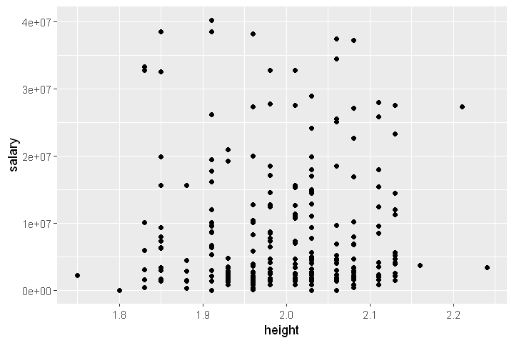

```r
ggplot(train_nba, aes(height, salary)) +
    geom_point()
```

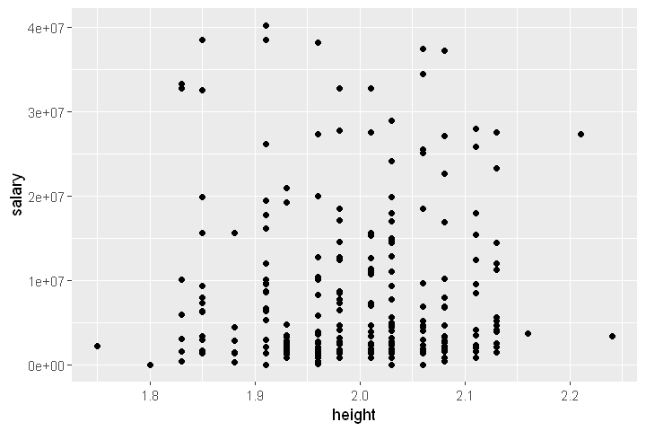

```r
last_plot()

# how to save a plot
Save <- TRUE

if (Save == TRUE) ggsave('plot.png', width = 7, height = 5)
```

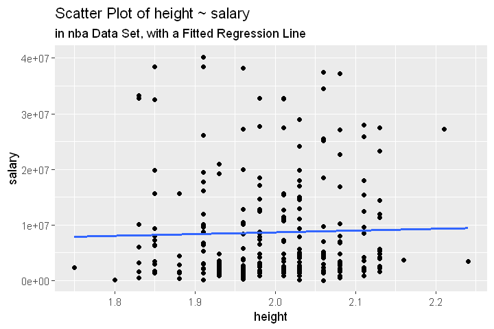

```r
train_nba %>% ggplot(aes(x = height, y = salary), na.rm = TRUE) +
    geom_point() +
    geom_smooth(method = 'lm', formula = y ~ x, se = FALSE, na.rm = TRUE) +
    labs(title = 'Scatter Plot of height ~ salary',
         subtitle = 'in nba Data Set, with a Fitted Regression Line')
Save <- TRUE

if (Save == TRUE) ggsave('plot2.png', width = 7, height = 5)
```

```r
summary_nba_weight <- train_nba %>%
    group_by(weight) %>%
    summarize(avg_salary = mean(salary, na.rm = TRUE)) %>%
    na.omit() %>%
    ungroup()
head(summary_nba_weight)
```

A tibble: 6 × 2

| weight <dbl> | avg_salary <dbl> |
| --- | --- |
| 170 | 1893148 |
| 171 | 6392760 |
| 172 | 32742000 |
| 174 | 8730240 |
| 175 | 12212070 |
| 178 | 3150000 |

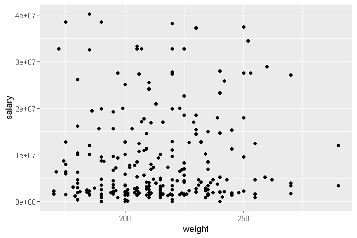

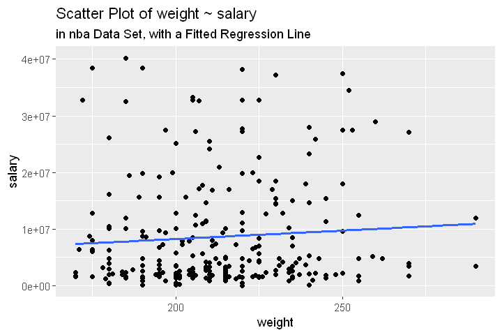

```r
ggplot(train_nba, aes(weight, salary)) +
    geom_point()

train_nba %>% ggplot(aes(x = weight, y = salary)) +
    geom_point() +
    geom_smooth(method = 'lm', formula = y ~ x, se = FALSE) +
    labs(title = 'Scatter Plot of weight ~ salary',
         subtitle = 'in nba Data Set, with a Fitted Regression Line')
Save <- TRUE

if (Save == TRUE) ggsave('plot3.png', width = 7, height = 5)
```

### Do younger players get paid more money than older players? or does the NBA reward veteran players?

We can observe a negative relationship between salary and your birth year. Or in other words, a positive relationship between salary and age. Older players seem to be getting paid significantly more than younger players. We can see how players born from 1997 to 2000, get paid the least amount in general, and its pretty much the same amount. This is because they have rookie contracts. Rookie contracts last 3-4 years, and unless you are a top 5 pick, you never get more than 3-5 milliion a year. We can also observe how players who were born between 1987 and 1992 are getting paid the most money. This is because those players are in their late 20s - early 30s, and those are usually your prime years.

```r
summary_nba_age <- train_nba %>%
    group_by(birth_year) %>%
    summarize(avg_salary = mean(salary, na.rm = TRUE)) %>%
    na.omit() %>%
    ungroup()
head(summary_nba_age)
```

A tibble: 6 × 2

| birth_year <dbl> | avg_salary <dbl> |
| --- | --- |
| 1982 | 2564753 |
| 1984 | 27311022 |
| 1985 | 19871730 |
| 1986 | 12420511 |
| 1987 | 16189943 |
| 1988 | 18228157 |

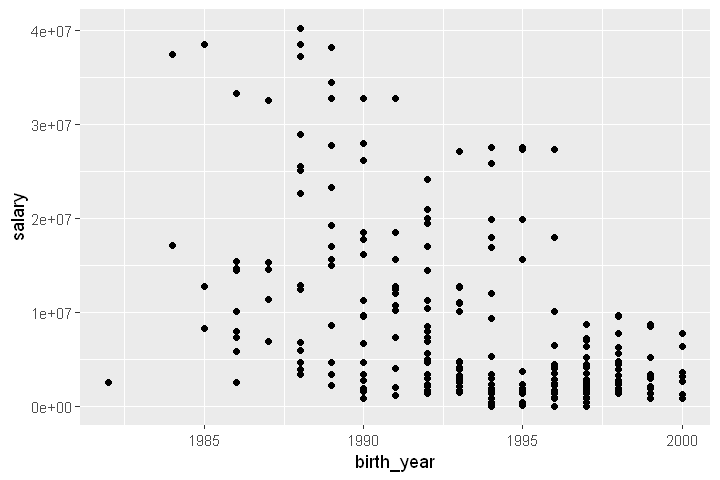

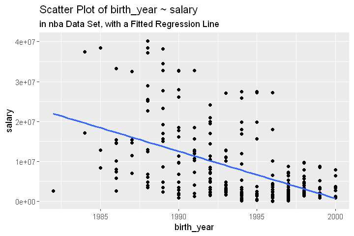

```r
ggplot(train_nba, aes(birth_year, salary)) +
    geom_point()

train_nba %>% ggplot(aes(x = birth_year, y = salary)) +
    geom_point() +
    geom_smooth(method = 'lm', formula = y ~ x, se = FALSE) +
    labs(title = 'Scatter Plot of birth_year ~ salary',
         subtitle = 'in nba Data Set, with a Fitted Regression Line')

Save <- TRUE

if (Save == TRUE) ggsave('plot4.png', width = 7, height = 5)
```

### Multiple Regression Model

Let's run a multiple regression, in which avg_salary is the dependent variable, and height, weight, and birth_year are the independent variables.

tidy() produces a tibble in which we see relevant information about my model. Something that caught my attention are the p-values. The p-values for height and weight, 0.66 and 0.83 respectively, are pretty high which indicates that my evidence is not strong enough to suggest that an significant effect exists between salary and height and weight. However, the p-value for birth_year is almost 0 which tells us there exists a clear relationship between salary and birth_year.

glance() report information about the entire model. I was able to show how well does the model fit the observed data. It turns out that it fits the model very well. Both the r.squared and the adj.r.squared have a value of >.7 .

augment() adds information about observations to my dataset which includes predicted values in the .fitted column, residuals in the .resid column, and standardized residual values in the .std.resid column. In the .fitted column, we see the values that are calculated after the best model that fits the data. Therefore we would want the .fitted columnn to be as close as the dependent variablee(salary), or in other words, we would want for the values in the .resid column to be as low as possible which would mean that our model is pretty close to the best model that fits the data possible.

```r
nba_mod1 <- summary_nba %>%
    lm(avg_salary ~ height + weight + birth_year, data = .)

tidy(nba_mod1)


glance(nba_mod1)

augment(nba_mod1)  %>% head()
```

[output not shown]

### Logistic regression

```r
#Create a df in which I only have US players
us_nba <- filter(train_nba, country == "USA")
head(us_nba)
us_nba %>%
    ggplot(aes(x = salary, y = draft_round)) +
    geom_point() +
    scale_color_manual(values = cbPalette) +
    labs(title = 'Scatter Plots of draft_round ~ salary per US NBA player')
```

```r
nba_mod2 <- us_nba %>%
        lm(draft_round ~ salary, data = ., na.action = na.exclude)
```

```r
tidy(nba_mod2)
```

[output not shown]

```r
glance(nba_mod2)
```

[output not shown]

```r
augment(nba_mod2) %>% head()
```

[output not shown]

```r
grid <- us_nba %>%
    data_grid(salary, draft_round) %>%
    gather_predictions(nba_mod2)

head(grid)
```

```r
us_nba %>%
    ggplot(aes(x = salary, y = draft_round)) +
    geom_point() +
    geom_line(data = grid, aes(salary, pred), color = 'blue') +
    scale_color_manual(values = cbPalette) +
    labs(title = 'Scatter Plots of draft_round ~ salary for US players',
         subtitle = 'Fitted with a Fitted Regression Line',
         y = 'draft_round')
```

[output not shown]

```r
us_nba %>%
    ggplot(aes(x = salary, y = draft_round)) +
    geom_point() +
    geom_smooth(method = 'lm', formula = y ~ x, se = FALSE) +
    scale_color_manual(values = cbPalette) +
    labs(title = 'Scatter Plots of draft_round ~ salary for US players',
        subtitle = 'Fitted with a Fitted Regression Line')
```

[output not shown]

```r
#let's do a little bit of cleaning first:
us_nba$salary_binned <- ifelse(us_nba$salary >= 0e+00 & us_nba$salary <= 1e+07, '0M-10M',
                  ifelse(us_nba$salary >=1e+07 & us_nba$salary <=2e+07, '10M-20M',
                         ifelse(us_nba$salary >=2e+07 & us_nba$salary <=3e+07, '20M-30M',
                                 ifelse(ifelse(us_nba$salary >=3e+07 & us_nba$salary <=5e+07, '30M-50M', 'something else')))))

us_nba <- us_nba %>%
    mutate(salary_binned = case_when(between(salary, 0e+00, 1e+07) ~ '0M-10M',
                                   between(salary, 1e+07, 2e+07) ~ '10M-20M',
                                   between(salary, 2e+07, 3e+07) ~ '20M-30M',
                                   between(salary, 3e+07, 5e+07) ~ '30M-50M')) %>%
    mutate_at(vars(salary_binned), factor)

head(us_nba)
tail(us_nba)
```

```r
bin_mids <- c(5e+6, 1.5e+07, 2.5e+07, 4e+07)

bin_avg <- us_nba %>%
    filter(!is.na(salary_binned)) %>%
    group_by(salary_binned) %>%
    summarize(bin_avg = mean(salary)) %>%
    select(bin_avg) %>%
    unlist(use.names = FALSE)

binned <- tibble(bin_mids, bin_avg)

binned
```

[output not shown]

```r
us_nba %>%
    filter(!is.na(salary_binned)) %>%
    ggplot() +
    geom_point(aes(x = salary, y = draft_round, color = salary_binned)) +
    geom_line(data = binned, aes(x = bin_mids, y = bin_avg), color = 'red') +

    scale_color_manual(values = cbPalette) +
    labs(title = 'Scatter Plots of draft_round ~ salary per US Nba player',
         subtitle = 'Fitted with a Fitted Regression Line')
```

```r
us_nba %>%
    filter(!is.na(salary_binned)) %>%
    ggplot() +
    geom_point(aes(x = salary, y = draft_round, color = salary_binned)) +
    geom_line(aes(x = salary, y = draft_round), color = 'red') +

    scale_color_manual(values = cbPalette) +
    labs(title = 'Scatter Plots of draft_round ~ salary per US Nba player',
         subtitle = 'Fitted with a Fitted Regression Line')
```

```r
us_nba %>%
    filter(!is.na(salary_binned)) %>%
    ggplot(aes(x = salary, y = draft_round)) +
    geom_point(aes(x = salary, y = draft_round, color = salary_binned)) +
    #geom_smooth(method = 'lm', formula = y ~ x, se = FALSE) +
    scale_color_manual(values = cbPalette) +
    labs(title = 'Scatter Plots of draft_round ~ salary per US Nba player',
         subtitle = 'Fitted with a Fitted Regression Line')
```

```r
us_nba %>%
    filter(!is.na(salary_binned)) %>%
    ggplot() +
    geom_point(aes(x = salary, y = draft_round, color = salary_binned)) +
    geom_line(data = binned, aes(x = bin_mids, y = bin_avg), color = 'red') +
    scale_y_continuous(limits = c(0, 4)) +
    scale_color_manual(values = cbPalette) +
    labs(title = 'Scatter Plots of draft_round ~ salary per US Nba player',
         subtitle = 'Fitted with a Fitted Regression Line')
Save <- TRUE

if (Save == TRUE) ggsave('plot5.png', width = 7, height = 5)
```

[output not shown]

A tibble: 6 × 16

[output not shown]

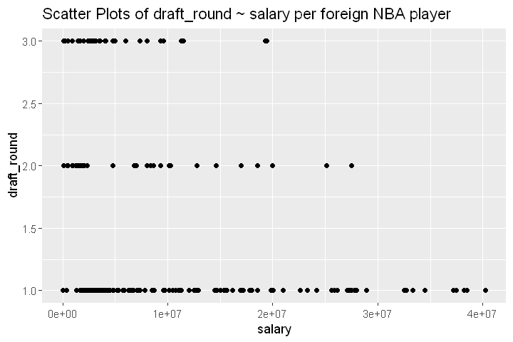

```r
#Create a df which only has foreign players
world_nba <- filter(train_nba, country != "USA")
head(us_nba)
train_nba %>%
    ggplot(aes(x = salary, y = draft_round)) +
    geom_point() +
    scale_color_manual(values = cbPalette) +
    labs(title = 'Scatter Plots of draft_round ~ salary per foreign NBA player')
```

```r
nba_mod3 <- world_nba %>%
        lm(draft_round ~ salary, data = ., na.action = na.exclude)

tidy(nba_mod3)

glance(nba_mod3)

augment(nba_mod3) %>% head()
```

A tibble: 2 × 5

| term <chr> | estimate <dbl> | std.error <dbl> | statistic <dbl> | p.value <dbl> |
| --- | --- | --- | --- | --- |
| (Intercept) | 1.823639e+00 | 1.300910e-01 | 14.018181 | 4.922880e-21 |
| salary | -2.805146e-08 | 1.086994e-08 | -2.580646 | 1.220321e-02 |

A tibble: 1 × 12

| r.squared <dbl> | adj.r.squared <dbl> | sigma <dbl> | statistic <dbl> | p.value <dbl> | df <dbl> | logLik <dbl> | AIC <dbl> | BIC <dbl> | deviance <dbl> | df.residual <int> | nobs <int> |
| --- | --- | --- | --- | --- | --- | --- | --- | --- | --- | --- | --- |
| 0.09560378 | 0.08124828 | 0.7364896 | 6.659734 | 0.01220321 | 1 | -71.33438 | 148.6688 | 155.1919 | 34.17226 | 63 | 65 |

A tibble: 6 × 8

| draft_round <dbl> | salary <dbl> | .fitted <dbl> | .resid <dbl> | .std.resid <dbl> | .hat <dbl> | .sigma <dbl> | .cooksd <dbl> |
| --- | --- | --- | --- | --- | --- | --- | --- |
| 1 | 25842697 | 1.098714 | -0.09871418 | -0.13979596 | 0.08074369 | 0.7422901 | 0.0008582844 |
| 1 | 27504630 | 1.052095 | -0.05209454 | -0.07430780 | 0.09388706 | 0.7423727 | 0.0002860633 |
| 2 | 27504630 | 1.052095 | 0.94790546 | 1.35209517 | 0.09388706 | 0.7315542 | 0.0947126349 |
| 1 | 27285000 | 1.058255 | -0.05825548 | -0.08301310 | 0.09208111 | 0.7423646 | 0.0003494514 |
| 1 | 2351838 | 1.757667 | -0.75766700 | -1.04115289 | 0.02367474 | 0.7359905 | 0.0131428569 |
| 1 | 28000000 | 1.038199 | -0.03819869 | -0.05461194 | 0.09803747 | 0.7423877 | 0.0001620872 |

```r
grid1 <- world_nba %>%
    data_grid(salary, draft_round) %>%
    gather_predictions(nba_mod3)

head(grid1)
```

A tibble: 6 × 4

| model <chr> | salary <dbl> | draft_round <dbl> | pred <dbl> |
| --- | --- | --- | --- |
| nba_mod3 | 79568 | 1 | 1.821407 |
| nba_mod3 | 79568 | 2 | 1.821407 |
| nba_mod3 | 79568 | 3 | 1.821407 |
| nba_mod3 | 898310 | 1 | 1.798441 |
| nba_mod3 | 898310 | 2 | 1.798441 |
| nba_mod3 | 898310 | 3 | 1.798441 |

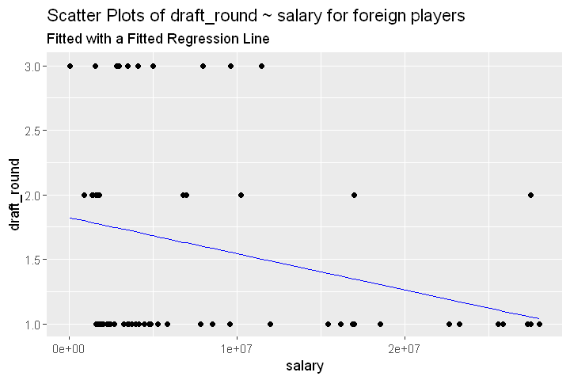

```r
world_nba %>%
    ggplot(aes(x = salary, y = draft_round)) +
    geom_point() +
    geom_line(data = grid1, aes(salary, pred), color = 'blue') +
    scale_color_manual(values = cbPalette) +
    labs(title = 'Scatter Plots of draft_round ~ salary for foreign players',
         subtitle = 'Fitted with a Fitted Regression Line',
         y = 'draft_round')
```

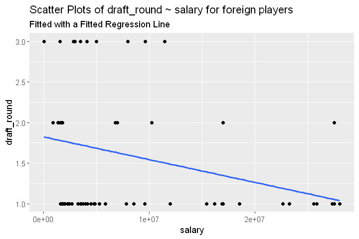

```r
world_nba %>%
    ggplot(aes(x = salary, y = draft_round)) +
    geom_point() +
    geom_smooth(method = 'lm', formula = y ~ x, se = FALSE) +
    scale_color_manual(values = cbPalette) +
    labs(title = 'Scatter Plots of draft_round ~ salary for foreign players',
        subtitle = 'Fitted with a Fitted Regression Line')
```

A tibble: 6 × 16

| name_rating <chr> | full_name <chr> | rating <dbl> | jersey <chr> | team <chr> | position <chr> | birth_year <dbl> | height <dbl> | weight <dbl> | salary <dbl> | country <chr> | draft_year <dbl> | draft_round <dbl> | draft_pick <dbl> | college <chr> | salary_binned <fct> |
| --- | --- | --- | --- | --- | --- | --- | --- | --- | --- | --- | --- | --- | --- | --- | --- |
| Giannis Antetokounmpo_96 | Giannis Antetokounmpo | 96 | #34 | Milwaukee Bucks | SF | 1994 | 2.11 | 242 | 25842697 | Greece | 2013 | 1 | 15 | NA | 20M-30M |
| Joel Embiid_91 | Joel Embiid | 91 | #21 | Philadelphia 76ers | C | 1994 | 2.13 | 250 | 27504630 | Cameroon | 2014 | 1 | 3 | Kansas | 20M-30M |
| Nikola Jokic_90 | Nikola Jokic | 90 | #15 | Denver Nuggets | C | 1995 | 2.13 | 253 | 27504630 | Serbia | 2014 | 2 | 41 | NA | 20M-30M |
| Kristaps Porzingis_87 | Kristaps Porzingis | 87 | #6 | Dallas Mavericks | PF | 1995 | 2.21 | 220 | 27285000 | Latvia | 2015 | 1 | 4 | NA | 20M-30M |
| Pascal Siakam_87 | Pascal Siakam | 87 | #43 | Toronto Raptors | F | 1994 | 2.06 | 227 | 2351838 | Cameroon | 2016 | 1 | 27 | New Mexico State | 0M-10M |
| Nikola Vucevic_86 | Nikola Vucevic | 86 | #9 | Orlando Magic | C | 1990 | 2.11 | 240 | 28000000 | Montenegro | 2011 | 1 | 16 | USC | 20M-30M |

A tibble: 3 × 2

| bin_mids <dbl> | bin_avg <dbl> |
| --- | --- |
| 5.0e+06 | 3738389 |
| 1.5e+07 | 14679965 |
| 2.5e+07 | 26121552 |

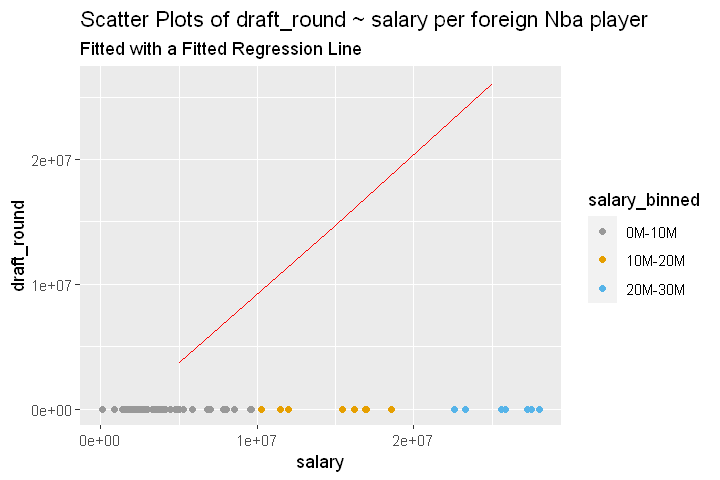

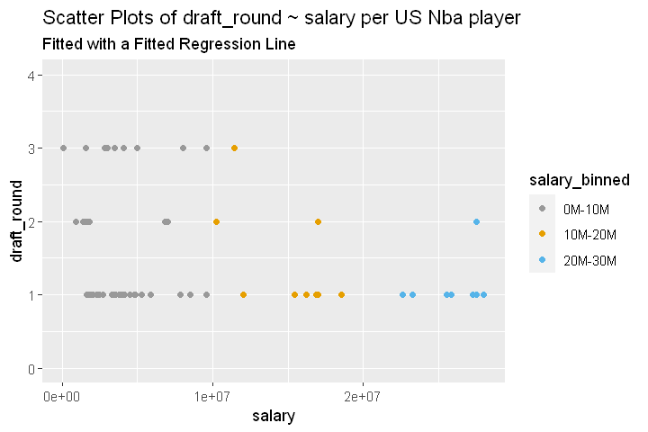

```r
#let's do a little bit of cleaning first:
world_nba$salary_binned <- ifelse(world_nba$salary >= 0e+00 & world_nba$salary <= 1e+07, '0M-10M',
                  ifelse(world_nba$salary >=1e+07 & world_nba$salary <=2e+07, '10M-20M',
                         ifelse(world_nba$salary >=2e+07 & world_nba$salary <=3e+07, '20M-30M',
                                 ifelse(ifelse(world_nba$salary >=3e+07 & world_nba$salary <=5e+07, '30M-50M', 'something else')))))

world_nba <- world_nba %>%
    mutate(salary_binned = case_when(between(salary, 0e+00, 1e+07) ~ '0M-10M',
                                   between(salary, 1e+07, 2e+07) ~ '10M-20M',
                                   between(salary, 2e+07, 3e+07) ~ '20M-30M',
                                   between(salary, 3e+07, 5e+07) ~ '30M-50M')) %>%
    mutate_at(vars(salary_binned), factor)

head(world_nba)

bin_mids <- c(5e+6, 1.5e+07, 2.5e+07)

bin_avg <- world_nba %>%
    filter(!is.na(salary_binned)) %>%
    group_by(salary_binned) %>%
    summarize(bin_avg = mean(salary)) %>%
    select(bin_avg) %>%
    unlist(use.names = FALSE)

binned <- tibble(bin_mids, bin_avg)

binned

world_nba %>%
    filter(!is.na(salary_binned)) %>%
    ggplot() +
    geom_point(aes(x = salary, y = draft_round, color = salary_binned)) +
    geom_line(data = binned, aes(x = bin_mids, y = bin_avg), color = 'red') +

    scale_color_manual(values = cbPalette) +
    labs(title = 'Scatter Plots of draft_round ~ salary per foreign Nba player',
         subtitle = 'Fitted with a Fitted Regression Line')

world_nba %>%
    filter(!is.na(salary_binned)) %>%
    ggplot() +
    geom_point(aes(x = salary, y = draft_round, color = salary_binned)) +
    geom_line(data = binned, aes(x = bin_mids, y = bin_avg), color = 'red') +
    scale_y_continuous(limits = c(0, 4)) +
    scale_color_manual(values = cbPalette) +
    labs(title = 'Scatter Plots of draft_round ~ salary per US Nba player',
         subtitle = 'Fitted with a Fitted Regression Line')
```

```r
bin_mids <- c(5e+6, 1.5e+07, 2.5e+07)

bin_avg <- world_nba %>%
    filter(!is.na(salary_binned)) %>%
    group_by(salary_binned) %>%
    summarize(bin_avg = mean(salary)) %>%
    select(bin_avg) %>%
    unlist(use.names = FALSE)

binned <- tibble(bin_mids, bin_avg)

binned
```

A tibble: 3 × 2

| bin_mids <dbl> | bin_avg <dbl> |
| --- | --- |
| 5.0e+06 | 3738389 |
| 1.5e+07 | 14679965 |
| 2.5e+07 | 26121552 |

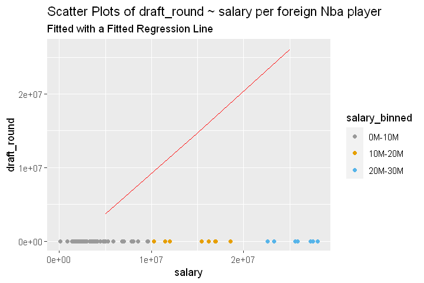

```r
world_nba %>%
    filter(!is.na(salary_binned)) %>%
    ggplot() +
    geom_point(aes(x = salary, y = draft_round, color = salary_binned)) +
    geom_line(data = binned, aes(x = bin_mids, y = bin_avg), color = 'red') +

    scale_color_manual(values = cbPalette) +
    labs(title = 'Scatter Plots of draft_round ~ salary per foreign Nba player',
         subtitle = 'Fitted with a Fitted Regression Line')
```

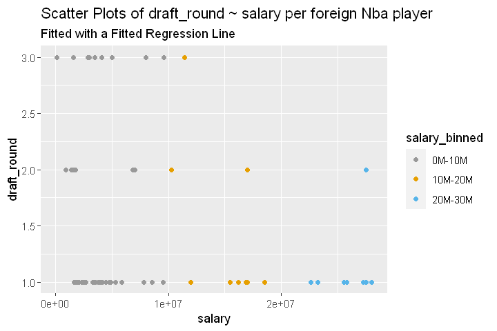

```r
world_nba %>%
    filter(!is.na(salary_binned)) %>%
    ggplot(aes(x = salary, y = draft_round)) +
    geom_point(aes(x = salary, y = draft_round, color = salary_binned)) +
    #geom_line(data = binned, aes(x = bin_mids, y = bin_avg), color = 'red') +
    #scale_y_continuous(limits = c(0, 4)) +
    scale_color_manual(values = cbPalette) +
    labs(title = 'Scatter Plots of draft_round ~ salary per foreign Nba player',
         subtitle = 'Fitted with a Fitted Regression Line')

Save <- TRUE

if (Save == TRUE) ggsave('plot7.png', width = 7, height = 5)
```

```r
#Comparing binned of US players vs binned of Foreign Players
bin_mids <- c(5e+6, 1.5e+07, 2.5e+07, 4e+07)

bin_avg <- us_nba %>%
    filter(!is.na(salary_binned)) %>%
    group_by(salary_binned) %>%
    summarize(bin_avg = mean(salary)) %>%
    select(bin_avg) %>%
    unlist(use.names = FALSE)

binned <- tibble(bin_mids, bin_avg)

binned

bin_mids <- c(5e+6, 1.5e+07, 2.5e+07)

bin_avg <- world_nba %>%
    filter(!is.na(salary_binned)) %>%
    group_by(salary_binned) %>%
    summarize(bin_avg = mean(salary)) %>%
    select(bin_avg) %>%
    unlist(use.names = FALSE)

binned <- tibble(bin_mids, bin_avg)

binned
```

A tibble: 4 × 2

| bin_mids <dbl> | bin_avg <dbl> |
| --- | --- |
| 5.0e+06 | 3361080 |
| 1.5e+07 | 14484793 |
| 2.5e+07 | 26421244 |
| 4.0e+07 | 36355470 |

A tibble: 3 × 2

| bin_mids <dbl> | bin_avg <dbl> |
| --- | --- |
| 5.0e+06 | 3738389 |
| 1.5e+07 | 14679965 |
| 2.5e+07 | 26121552 |

### Applying my models to my testing dataset

Everything seems to be the same except that on my log. regression, my dependent variable is constant. It must be from a coding error or something that I've cleaned in my train_nba dataset and not in my train_nba, but I cannot seem to figure out what it is.

```r
head(test_nba)
```

A tibble: 6 × 15

| name_rating <chr> | full_name <chr> | rating <dbl> | jersey <chr> | team <chr> | position <chr> | birth_year <dbl> | height <dbl> | weight <dbl> | salary <dbl> | country <chr> | draft_year <dbl> | draft_round <dbl> | draft_pick <dbl> | college <chr> |
| --- | --- | --- | --- | --- | --- | --- | --- | --- | --- | --- | --- | --- | --- | --- |
| Anthony Davis_94 | Anthony Davis | 94 | #3 | Los Angeles Lakers | PF | 1993 | 2.08 | 222 | 27093019 | USA | 2012 | 1 | 1 | Kentucky |
| Paul George_93 | Paul George | 93 | #13 | Los Angeles Clippers | F | 1990 | 2.03 | 210 | 33005556 | USA | 2010 | 1 | 10 | Fresno State |
| Damian Lillard_92 | Damian Lillard | 92 | #0 | Portland Trail Blazers | G | 1990 | 1.88 | 195 | 29802321 | USA | 2012 | 1 | 6 | Weber State |
| Kyrie Irving_91 | Kyrie Irving | 91 | #11 | Brooklyn Nets | G | 1992 | 1.88 | 180 | 31742000 | Australia | 2011 | 1 | 1 | Duke |
| Karl-Anthony Towns_89 | Karl-Anthony Towns | 89 | #32 | Minnesota Timberwolves | PF | 1995 | 2.11 | 248 | 27285000 | USA | 2015 | 1 | 1 | Kentucky |
| Rudy Gobert_88 | Rudy Gobert | 88 | #27 | Utah Jazz | C | 1992 | 2.16 | 238 | 25258427 | France | 2013 | 1 | 27 | NA |

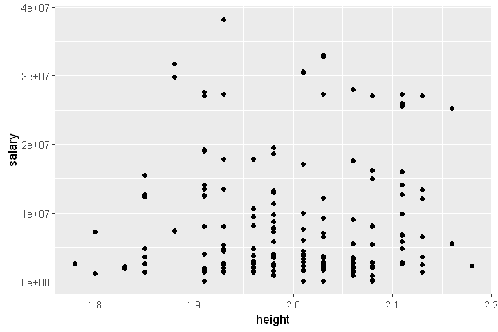

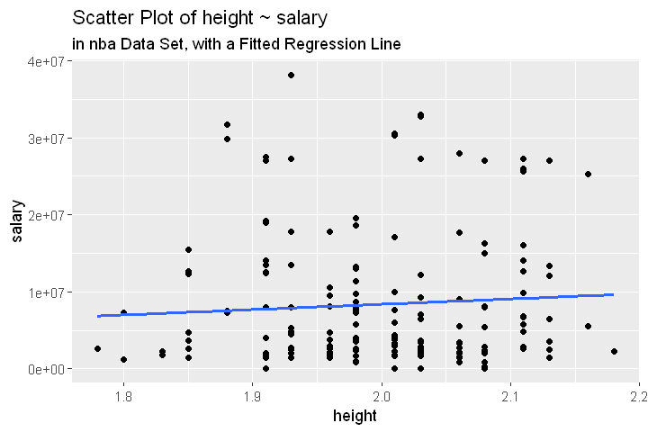

```r
#For the relationship between height and salary:
summary_nba_height <- test_nba %>%
    group_by(height) %>%
    summarize(avg_salary = mean(salary, na.rm = TRUE)) %>%
    na.omit() %>%
    ungroup()
#Height is in meters, therefore 1.8m = 6', 1.9m = 6'3'', 2m = 6'6'', 2.10m = 6'10'', 2.2m = 7'2''
ggplot(test_nba, aes(height, salary), na.rm = TRUE) +
    geom_point()

test_nba %>% ggplot(aes(x = height, y = salary), na.rm = TRUE) +
    geom_point() +
    geom_smooth(method = 'lm', formula = y ~ x, se = FALSE, na.rm = TRUE) +
    labs(title = 'Scatter Plot of height ~ salary',
         subtitle = 'in nba Data Set, with a Fitted Regression Line')
```

```r
summary_nba_weight <- train_nba %>%
    group_by(weight) %>%
    summarize(avg_salary = mean(salary, na.rm = TRUE)) %>%
    na.omit() %>%
    ungroup()
head(summary_nba_weight)
```

[output not shown]

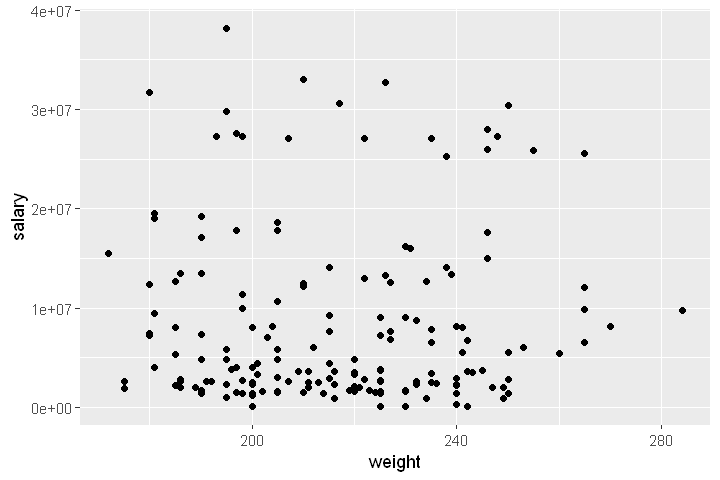

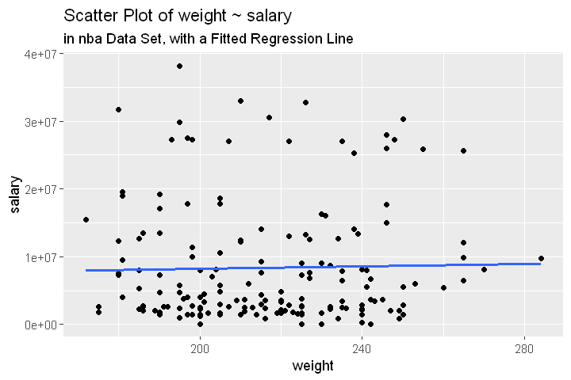

```r
ggplot(test_nba, aes(weight, salary)) +
    geom_point()

test_nba %>% ggplot(aes(x = weight, y = salary)) +
    geom_point() +
    geom_smooth(method = 'lm', formula = y ~ x, se = FALSE) +
    labs(title = 'Scatter Plot of weight ~ salary',
         subtitle = 'in nba Data Set, with a Fitted Regression Line')
```

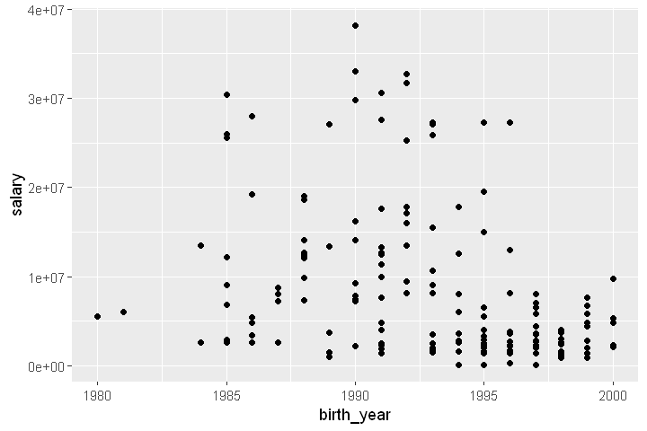

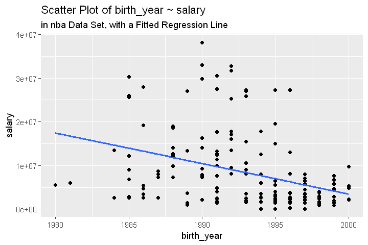

```r
ggplot(test_nba, aes(birth_year, salary)) +
    geom_point()

test_nba %>% ggplot(aes(x = birth_year, y = salary)) +
    geom_point() +
    geom_smooth(method = 'lm', formula = y ~ x, se = FALSE) +
    labs(title = 'Scatter Plot of birth_year ~ salary',
         subtitle = 'in nba Data Set, with a Fitted Regression Line')
```

```r
#The multiple regression:
nba_mod1 <- summary_nba %>%
    lm(avg_salary ~ height + weight + birth_year, data = .)

tidy(nba_mod1)


glance(nba_mod1)

augment(nba_mod1)  %>% head()
```

A tibble: 4 × 5

| term <chr> | estimate <dbl> | std.error <dbl> | statistic <dbl> | p.value <dbl> |
| --- | --- | --- | --- | --- |
| (Intercept) | 2.358599e+09 | 79982399.43 | 29.4889809 | 7.873870e-84 |
| height | 1.226363e+06 | 2750721.88 | 0.4458333 | 6.560990e-01 |
| weight | -2.170605e+03 | 10028.99 | -0.2164331 | 8.288246e-01 |
| birth_year | -1.179924e+06 | 40232.42 | -29.3276803 | 2.306649e-83 |

A tibble: 1 × 12

| r.squared <dbl> | adj.r.squared <dbl> | sigma <dbl> | statistic <dbl> | p.value <dbl> | df <dbl> | logLik <dbl> | AIC <dbl> | BIC <dbl> | deviance <dbl> | df.residual <int> | nobs <int> |
| --- | --- | --- | --- | --- | --- | --- | --- | --- | --- | --- | --- |
| 0.7757032 | 0.7730435 | 2509003 | 291.6566 | 8.496623e-82 | 3 | -4149.648 | 8309.296 | 8327.042 | 1.592659e+15 | 253 | 257 |

A tibble: 6 × 10

| avg_salary <dbl> | height <dbl> | weight <dbl> | birth_year <dbl> | .fitted <dbl> | .resid <dbl> | .std.resid <dbl> | .hat <dbl> | .sigma <dbl> | .cooksd <dbl> |
| --- | --- | --- | --- | --- | --- | --- | --- | --- | --- |
| 2564753 | 2.13 | 235 | 1982 | 22092760 | -19528007 | -7.9802631 | 0.04878412 | 2174673 | 0.816533207 |
| 27311022 | 2.06 | 250 | 1984 | 19614508 | 7696513 | 3.1208668 | 0.03387072 | 2465111 | 0.085364955 |
| 27311022 | 1.98 | 207 | 1984 | 19609735 | 7701286 | 3.1113996 | 0.02677640 | 2465410 | 0.066587269 |
| 19871730 | 1.85 | 175 | 1985 | 18339844 | 1531887 | 0.6215605 | 0.03509578 | 2512056 | 0.003512995 |
| 19871730 | 1.96 | 225 | 1985 | 18366213 | 1505517 | 0.6077421 | 0.02516658 | 2512140 | 0.002383814 |
| 19871730 | 1.96 | 200 | 1985 | 18420478 | 1451252 | 0.5853484 | 0.02354006 | 2512273 | 0.002065009 |

A tibble: 6 × 15

| name_rating <chr> | full_name <chr> | rating <dbl> | jersey <chr> | team <chr> | position <chr> | birth_year <dbl> | height <dbl> | weight <dbl> | salary <dbl> | country <chr> | draft_year <dbl> | draft_round <dbl> | draft_pick <dbl> | college <chr> |
| --- | --- | --- | --- | --- | --- | --- | --- | --- | --- | --- | --- | --- | --- | --- |
| Anthony Davis_94 | Anthony Davis | 94 | #3 | Los Angeles Lakers | PF | 1993 | 2.08 | 222 | 27093019 | USA | 2012 | 1 | 1 | Kentucky |
| Damian Lillard_92 | Damian Lillard | 92 | #0 | Portland Trail Blazers | G | 1990 | 1.88 | 195 | 29802321 | USA | 2012 | 1 | 6 | Weber State |
| Karl-Anthony Towns_89 | Karl-Anthony Towns | 89 | #32 | Minnesota Timberwolves | PF | 1995 | 2.11 | 248 | 27285000 | USA | 2015 | 1 | 1 | Kentucky |
| Donovan Mitchell_88 | Donovan Mitchell | 88 | #45 | Utah Jazz | G | 1996 | 1.85 | 211 | 3635760 | USA | 2017 | 1 | 13 | Louisville |
| LaMarcus Aldridge_87 | LaMarcus Aldridge | 87 | #12 | San Antonio Spurs | PF | 1985 | 2.11 | 246 | 26000000 | USA | 2006 | 1 | 2 | Texas |
| CJ McCollum_87 | CJ McCollum | 87 | #3 | Portland Trail Blazers | G | 1991 | 1.91 | 197 | 27556959 | USA | 2013 | 1 | 10 | Lehigh |

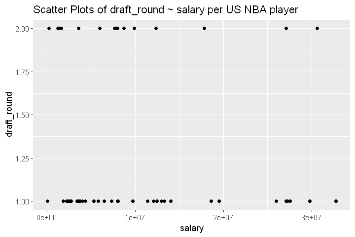

```r
#Let's have a look at the log. regression:

#Create a df in which I only have US players
us_nba <- filter(test_nba, country == "USA", draft_round == c(1,2))
head(us_nba)
us_nba %>%
    ggplot(aes(x = salary, y = draft_round)) +
    geom_point() +
    scale_color_manual(values = cbPalette) +
    labs(title = 'Scatter Plots of draft_round ~ salary per US NBA player')
```

```r
nba_mod2 <- us_nba %>%
        lm(draft_round ~ salary, data = ., na.action = na.exclude)
tidy(nba_mod2)
glance(nba_mod2)
augment(nba_mod2) %>% head()
```

A tibble: 2 × 5

| term <chr> | estimate <dbl> | std.error <dbl> | statistic <dbl> | p.value <dbl> |
| --- | --- | --- | --- | --- |
| (Intercept) | 1.357630e+00 | 8.844651e-02 | 15.3497256 | 6.613041e-22 |
| salary | -5.380759e-09 | 6.593907e-09 | -0.8160197 | 4.178860e-01 |

A tibble: 1 × 12

| r.squared <dbl> | adj.r.squared <dbl> | sigma <dbl> | statistic <dbl> | p.value <dbl> | df <dbl> | logLik <dbl> | AIC <dbl> | BIC <dbl> | deviance <dbl> | df.residual <int> | nobs <int> |
| --- | --- | --- | --- | --- | --- | --- | --- | --- | --- | --- | --- |
| 0.01154735 | -0.005793924 | 0.4657391 | 0.6658882 | 0.417886 | 1 | -37.61638 | 81.23276 | 87.46537 | 12.36403 | 57 | 59 |

A tibble: 6 × 8

| draft_round <dbl> | salary <dbl> | .fitted <dbl> | .resid <dbl> | .std.resid <dbl> | .hat <dbl> | .sigma <dbl> | .cooksd <dbl> |
| --- | --- | --- | --- | --- | --- | --- | --- |
| 1 | 27093019 | 1.211849 | -0.2118487 | -0.4734930 | 0.07713317 | 0.4689541 | 0.009369130 |
| 1 | 29802321 | 1.197271 | -0.1972706 | -0.4458389 | 0.09742489 | 0.4690591 | 0.010727845 |
| 1 | 27285000 | 1.210816 | -0.2108157 | -0.4715269 | 0.07847417 | 0.4689618 | 0.009466777 |
| 1 | 3635760 | 1.338067 | -0.3380665 | -0.7349224 | 0.02448031 | 0.4676476 | 0.006776942 |
| 1 | 26000000 | 1.217730 | -0.2177300 | -0.4847107 | 0.06977991 | 0.4689097 | 0.008812111 |
| 1 | 27556959 | 1.209352 | -0.2093523 | -0.4687437 | 0.08039911 | 0.4689726 | 0.009604897 |

```r
grid <- us_nba %>%
    data_grid(salary, draft_round) %>%
    gather_predictions(nba_mod2)

head(grid)
```

```r
us_nba %>%
    ggplot(aes(x = salary, y = draft_round)) +
    geom_point() +
    geom_line(data = grid, aes(salary, pred), color = 'blue') +
    scale_color_manual(values = cbPalette) +
    labs(title = 'Scatter Plots of draft_round ~ salary for US players',
         subtitle = 'Fitted with a Fitted Regression Line',
         y = 'draft_round')

us_nba %>%
    ggplot(aes(x = salary, y = draft_round)) +
    geom_point() +
    geom_smooth(method = 'lm', formula = y ~ x, se = FALSE) +
    scale_color_manual(values = cbPalette) +
    labs(title = 'Scatter Plots of draft_round ~ salary for US players',
        subtitle = 'Fitted with a Fitted Regression Line')
```

```r
#let's do a little bit of cleaning first:
us_nba$salary_binned <- ifelse(us_nba$salary >= 0e+00 & us_nba$salary <= 1e+07, '0M-10M',
                  ifelse(us_nba$salary >=1e+07 & us_nba$salary <=2e+07, '10M-20M',
                         ifelse(us_nba$salary >=2e+07 & us_nba$salary <=3e+07, '20M-30M',
                                 ifelse(ifelse(us_nba$salary >=3e+07 & us_nba$salary <=5e+07, '30M-50M', 'something else')))))

us_nba <- us_nba %>%
    mutate(salary_binned = case_when(between(salary, 0e+00, 1e+07) ~ '0M-10M',
                                   between(salary, 1e+07, 2e+07) ~ '10M-20M',
                                   between(salary, 2e+07, 3e+07) ~ '20M-30M',
                                   between(salary, 3e+07, 5e+07) ~ '30M-50M')) %>%
    mutate_at(vars(salary_binned), factor)

head(us_nba)
tail(us_nba)
```

A tibble: 6 × 16

| name_rating <chr> | full_name <chr> | rating <dbl> | jersey <chr> | team <chr> | position <chr> | birth_year <dbl> | height <dbl> | weight <dbl> | salary <dbl> | country <chr> | draft_year <dbl> | draft_round <dbl> | draft_pick <dbl> | college <chr> | salary_binned <fct> |
| --- | --- | --- | --- | --- | --- | --- | --- | --- | --- | --- | --- | --- | --- | --- | --- |
| Anthony Davis_94 | Anthony Davis | 94 | #3 | Los Angeles Lakers | PF | 1993 | 2.08 | 222 | 27093019 | USA | 2012 | 1 | 1 | Kentucky | 20M-30M |
| Damian Lillard_92 | Damian Lillard | 92 | #0 | Portland Trail Blazers | G | 1990 | 1.88 | 195 | 29802321 | USA | 2012 | 1 | 6 | Weber State | 20M-30M |
| Karl-Anthony Towns_89 | Karl-Anthony Towns | 89 | #32 | Minnesota Timberwolves | PF | 1995 | 2.11 | 248 | 27285000 | USA | 2015 | 1 | 1 | Kentucky | 20M-30M |
| Donovan Mitchell_88 | Donovan Mitchell | 88 | #45 | Utah Jazz | G | 1996 | 1.85 | 211 | 3635760 | USA | 2017 | 1 | 13 | Louisville | 0M-10M |
| LaMarcus Aldridge_87 | LaMarcus Aldridge | 87 | #12 | San Antonio Spurs | PF | 1985 | 2.11 | 246 | 26000000 | USA | 2006 | 1 | 2 | Texas | 20M-30M |
| CJ McCollum_87 | CJ McCollum | 87 | #3 | Portland Trail Blazers | G | 1991 | 1.91 | 197 | 27556959 | USA | 2013 | 1 | 10 | Lehigh | 20M-30M |

A tibble: 6 × 16

| name_rating <chr> | full_name <chr> | rating <dbl> | jersey <chr> | team <chr> | position <chr> | birth_year <dbl> | height <dbl> | weight <dbl> | salary <dbl> | country <chr> | draft_year <dbl> | draft_round <dbl> | draft_pick <dbl> | college <chr> | salary_binned <fct> |
| --- | --- | --- | --- | --- | --- | --- | --- | --- | --- | --- | --- | --- | --- | --- | --- |
| Frank Jackson_71 | Frank Jackson | 71 | #15 | New Orleans Pelicans | G | 1998 | 1.91 | 205 | 1618520 | USA | 2017 | 2 | 31 | Duke | 0M-10M |
| Carsen Edwards_71 | Carsen Edwards | 71 | #4 | Boston Celtics | G | 1998 | 1.80 | 200 | 1228026 | USA | 2019 | 2 | 33 | Purdue | 0M-10M |
| Darius Bazley_70 | Darius Bazley | 70 | #7 | Oklahoma City Thunder | F | 2000 | 2.03 | 200 | 2284800 | USA | 2019 | 1 | 23 | NA | 0M-10M |
| Hamidou Diallo_70 | Hamidou Diallo | 70 | #6 | Oklahoma City Thunder | G | 1998 | 1.96 | 198 | 1416852 | USA | 2018 | 2 | 45 | Kentucky | 0M-10M |
| Solomon Hill_70 | Solomon Hill | 70 | #44 | Miami Heat | F | 1991 | 1.98 | 226 | 13290395 | USA | 2013 | 1 | 23 | Arizona | 10M-20M |
| Henry Ellenson_69 | Henry Ellenson | 69 | #0 | NA | PF | 1997 | 2.08 | 242 | 79568 | USA | 2016 | 1 | 18 | Marquette | 0M-10M |

```r
bin_mids <- c(5e+6, 1.5e+07, 2.5e+07, 4e+07)

bin_avg <- us_nba %>%
    filter(!is.na(salary_binned)) %>%
    group_by(salary_binned) %>%
    summarize(bin_avg = mean(salary)) %>%
    select(bin_avg) %>%
    unlist(use.names = FALSE)

binned <- tibble(bin_mids, bin_avg)

binned
```

A tibble: 4 × 2

| bin_mids <dbl> | bin_avg <dbl> |
| --- | --- |
| 5.0e+06 | 9765338 |
| 1.5e+07 | 9765338 |
| 2.5e+07 | 9765338 |
| 4.0e+07 | 9765338 |

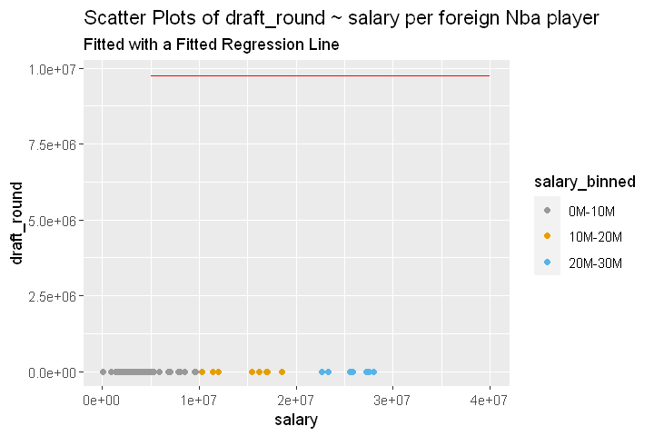

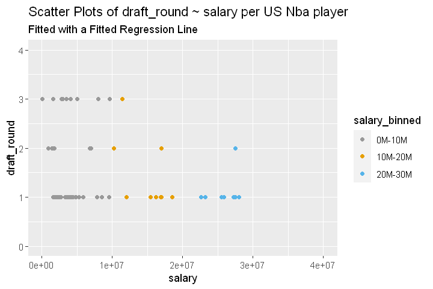

```r
world_nba %>%
    filter(!is.na(salary_binned)) %>%
    ggplot() +
    geom_point(aes(x = salary, y = draft_round, color = salary_binned)) +
    geom_line(data = binned, aes(x = bin_mids, y = bin_avg), color = 'red') +

    scale_color_manual(values = cbPalette) +
    labs(title = 'Scatter Plots of draft_round ~ salary per foreign Nba player',
         subtitle = 'Fitted with a Fitted Regression Line')
world_nba %>%
    filter(!is.na(salary_binned)) %>%
    ggplot() +
    geom_point(aes(x = salary, y = draft_round, color = salary_binned)) +
    geom_line(data = binned, aes(x = bin_mids, y = bin_avg), color = 'red') +
    scale_y_continuous(limits = c(0, 4)) +
    scale_color_manual(values = cbPalette) +
    labs(title = 'Scatter Plots of draft_round ~ salary per US Nba player',
         subtitle = 'Fitted with a Fitted Regression Line')
```

A tibble: 6 × 16

| name_rating <chr> | full_name <chr> | rating <dbl> | jersey <chr> | team <chr> | position <chr> | birth_year <dbl> | height <dbl> | weight <dbl> | salary <dbl> | country <chr> | draft_year <dbl> | draft_round <dbl> | draft_pick <dbl> | college <chr> | salary_binned <fct> |
| --- | --- | --- | --- | --- | --- | --- | --- | --- | --- | --- | --- | --- | --- | --- | --- |
| Anthony Davis_94 | Anthony Davis | 94 | #3 | Los Angeles Lakers | PF | 1993 | 2.08 | 222 | 27093019 | USA | 2012 | 1 | 1 | Kentucky | 20M-30M |
| Damian Lillard_92 | Damian Lillard | 92 | #0 | Portland Trail Blazers | G | 1990 | 1.88 | 195 | 29802321 | USA | 2012 | 1 | 6 | Weber State | 20M-30M |
| Karl-Anthony Towns_89 | Karl-Anthony Towns | 89 | #32 | Minnesota Timberwolves | PF | 1995 | 2.11 | 248 | 27285000 | USA | 2015 | 1 | 1 | Kentucky | 20M-30M |
| Donovan Mitchell_88 | Donovan Mitchell | 88 | #45 | Utah Jazz | G | 1996 | 1.85 | 211 | 3635760 | USA | 2017 | 1 | 13 | Louisville | 0M-10M |
| LaMarcus Aldridge_87 | LaMarcus Aldridge | 87 | #12 | San Antonio Spurs | PF | 1985 | 2.11 | 246 | 26000000 | USA | 2006 | 1 | 2 | Texas | 20M-30M |
| CJ McCollum_87 | CJ McCollum | 87 | #3 | Portland Trail Blazers | G | 1991 | 1.91 | 197 | 27556959 | USA | 2013 | 1 | 10 | Lehigh | 20M-30M |

A tibble: 2 × 5

| term <chr> | estimate <dbl> | std.error <dbl> | statistic <dbl> | p.value <dbl> |
| --- | --- | --- | --- | --- |
| (Intercept) | 1.676654e+00 | 1.517973e-01 | 11.045346 | 1.422998e-13 |
| salary | -1.818707e-08 | 1.223700e-08 | -1.486237 | 1.452566e-01 |

A tibble: 1 × 12

| r.squared <dbl> | adj.r.squared <dbl> | sigma <dbl> | statistic <dbl> | p.value <dbl> | df <dbl> | logLik <dbl> | AIC <dbl> | BIC <dbl> | deviance <dbl> | df.residual <int> | nobs <int> |
| --- | --- | --- | --- | --- | --- | --- | --- | --- | --- | --- | --- |
| 0.05360248 | 0.02933587 | 0.6653702 | 2.208899 | 0.1452566 | 1 | -40.44739 | 86.89478 | 92.03549 | 17.26598 | 39 | 41 |

A tibble: 6 × 8

| draft_round <dbl> | salary <dbl> | .fitted <dbl> | .resid <dbl> | .std.resid <dbl> | .hat <dbl> | .sigma <dbl> | .cooksd <dbl> |
| --- | --- | --- | --- | --- | --- | --- | --- |
| 1 | 31742000 | 1.099360 | -0.09935993 | -0.1668179 | 0.19867155 | 0.6738277 | 0.003449693 |
| 1 | 25258427 | 1.217277 | -0.21727716 | -0.3467927 | 0.11333080 | 0.6730281 | 0.007685925 |
| 1 | 7683360 | 1.536916 | -0.53691620 | -0.8172298 | 0.02501518 | 0.6682717 | 0.008567698 |
| 1 | 8113929 | 1.529085 | -0.52908541 | -0.8051732 | 0.02468197 | 0.6684422 | 0.008203178 |
| 1 | 28000000 | 1.167416 | -0.16741596 | -0.2722646 | 0.14594709 | 0.6734273 | 0.006333779 |
| 1 | 4444746 | 1.595817 | -0.59581711 | -0.9099320 | 0.03154078 | 0.6668746 | 0.013482764 |

A tibble: 6 × 4

| model <chr> | salary <dbl> | draft_round <dbl> | pred <dbl> |
| --- | --- | --- | --- |
| nba_mod3 | 898310 | 1 | 1.660316 |
| nba_mod3 | 898310 | 2 | 1.660316 |
| nba_mod3 | 898310 | 3 | 1.660316 |
| nba_mod3 | 1416852 | 1 | 1.650886 |
| nba_mod3 | 1416852 | 2 | 1.650886 |
| nba_mod3 | 1416852 | 3 | 1.650886 |

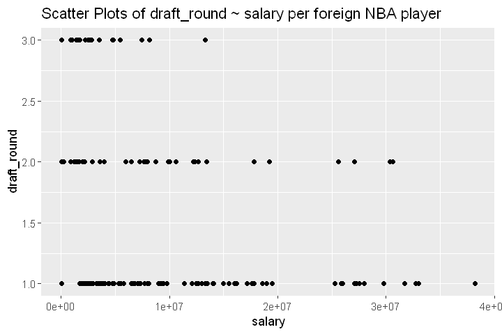

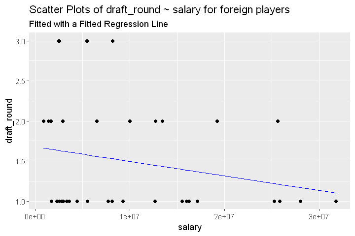

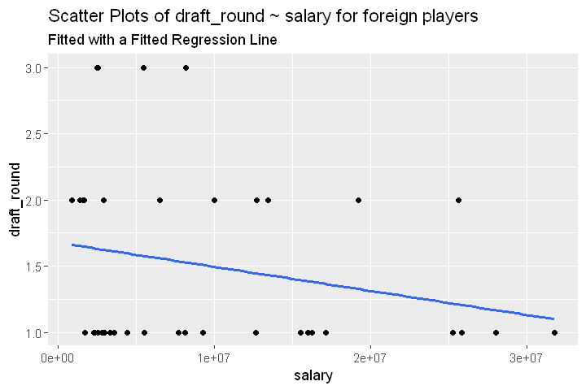

```r
#Create a df which only has foreign players
world_nba <- filter(test_nba, country != "USA")
head(us_nba)
test_nba %>%
    ggplot(aes(x = salary, y = draft_round)) +
    geom_point() +
    scale_color_manual(values = cbPalette) +
    labs(title = 'Scatter Plots of draft_round ~ salary per foreign NBA player')

nba_mod3 <- world_nba %>%
        lm(draft_round ~ salary, data = ., na.action = na.exclude)

tidy(nba_mod3)

glance(nba_mod3)

augment(nba_mod3) %>% head()

grid1 <- world_nba %>%
    data_grid(salary, draft_round) %>%
    gather_predictions(nba_mod3)

head(grid1)

world_nba %>%
    ggplot(aes(x = salary, y = draft_round)) +
    geom_point() +
    geom_line(data = grid1, aes(salary, pred), color = 'blue') +
    scale_color_manual(values = cbPalette) +
    labs(title = 'Scatter Plots of draft_round ~ salary for foreign players',
         subtitle = 'Fitted with a Fitted Regression Line',
         y = 'draft_round')

world_nba %>%
    ggplot(aes(x = salary, y = draft_round)) +
    geom_point() +
    geom_smooth(method = 'lm', formula = y ~ x, se = FALSE) +
    scale_color_manual(values = cbPalette) +
    labs(title = 'Scatter Plots of draft_round ~ salary for foreign players',
        subtitle = 'Fitted with a Fitted Regression Line')
```

A tibble: 6 × 16

| name_rating <chr> | full_name <chr> | rating <dbl> | jersey <chr> | team <chr> | position <chr> | birth_year <dbl> | height <dbl> | weight <dbl> | salary <dbl> | country <chr> | draft_year <dbl> | draft_round <dbl> | draft_pick <dbl> | college <chr> | salary_binned <fct> |
| --- | --- | --- | --- | --- | --- | --- | --- | --- | --- | --- | --- | --- | --- | --- | --- |
| Kyrie Irving_91 | Kyrie Irving | 91 | #11 | Brooklyn Nets | G | 1992 | 1.88 | 180 | 31742000 | Australia | 2011 | 1 | 1 | Duke | 30M-50M |
| Rudy Gobert_88 | Rudy Gobert | 88 | #27 | Utah Jazz | C | 1992 | 2.16 | 238 | 25258427 | France | 2013 | 1 | 27 | NA | 20M-30M |
| Luka Doncic_87 | Luka Doncic | 87 | #77 | Dallas Mavericks | SG | 1999 | 2.01 | 227 | 7683360 | Slovenia | 2018 | 1 | 3 | NA | 0M-10M |
| Ben Simmons_87 | Ben Simmons | 87 | #25 | Philadelphia 76ers | F | 1996 | 2.08 | 240 | 8113929 | Australia | 2016 | 1 | 1 | LSU | 0M-10M |
| Al Horford_85 | Al Horford | 85 | #42 | Philadelphia 76ers | PF | 1986 | 2.06 | 246 | 28000000 | Dominican Republic | 2007 | 1 | 3 | Florida | 20M-30M |
| Jamal Murray_84 | Jamal Murray | 84 | #27 | Denver Nuggets | G | 1997 | 1.93 | 201 | 4444746 | Canada | 2016 | 1 | 7 | Kentucky | 0M-10M |

A tibble: 3 × 2

| bin_mids <dbl> | bin_avg <dbl> |
| --- | --- |
| 5.0e+06 | 9042626 |
| 1.5e+07 | 9042626 |
| 2.5e+07 | 9042626 |

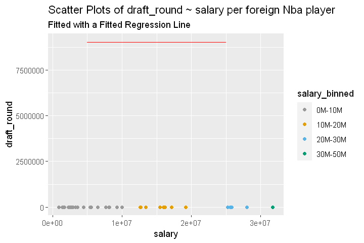

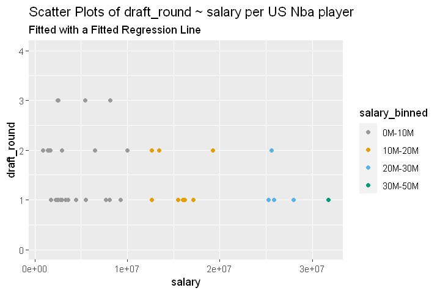

```r
#let's do a little bit of cleaning first:
world_nba$salary_binned <- ifelse(world_nba$salary >= 0e+00 & world_nba$salary <= 1e+07, '0M-10M',
                  ifelse(world_nba$salary >=1e+07 & world_nba$salary <=2e+07, '10M-20M',
                         ifelse(world_nba$salary >=2e+07 & world_nba$salary <=3e+07, '20M-30M',
                                 ifelse(ifelse(world_nba$salary >=3e+07 & world_nba$salary <=5e+07, '30M-50M', 'something else')))))

world_nba <- world_nba %>%
    mutate(salary_binned = case_when(between(salary, 0e+00, 1e+07) ~ '0M-10M',
                                   between(salary, 1e+07, 2e+07) ~ '10M-20M',
                                   between(salary, 2e+07, 3e+07) ~ '20M-30M',
                                   between(salary, 3e+07, 5e+07) ~ '30M-50M')) %>%
    mutate_at(vars(salary_binned), factor)

head(world_nba)

bin_mids <- c(5e+6, 1.5e+07, 2.5e+07)

bin_avg <- world_nba %>%
    filter(!is.na(salary_binned)) %>%
    group_by(salary_binned) %>%
    summarize(bin_avg = mean(salary)) %>%
    select(bin_avg) %>%
    unlist(use.names = FALSE)

binned <- tibble(bin_mids, bin_avg)

binned

world_nba %>%
    filter(!is.na(salary_binned)) %>%
    ggplot() +
    geom_point(aes(x = salary, y = draft_round, color = salary_binned)) +
    geom_line(data = binned, aes(x = bin_mids, y = bin_avg), color = 'red') +

    scale_color_manual(values = cbPalette) +
    labs(title = 'Scatter Plots of draft_round ~ salary per foreign Nba player',
         subtitle = 'Fitted with a Fitted Regression Line')

world_nba %>%
    filter(!is.na(salary_binned)) %>%
    ggplot() +
    geom_point(aes(x = salary, y = draft_round, color = salary_binned)) +
    geom_line(data = binned, aes(x = bin_mids, y = bin_avg), color = 'red') +
    scale_y_continuous(limits = c(0, 4)) +
    scale_color_manual(values = cbPalette) +
    labs(title = 'Scatter Plots of draft_round ~ salary per US Nba player',
         subtitle = 'Fitted with a Fitted Regression Line')
```